# PML2023_HW1_HigaZ

## SP23:CS 477/577: Python for Machine Learning

### Homework 1: Python for basic data processing

Student Name: Higa, Zachary

Department: Statistics

This homework aims to help you practice basic Python programing skills using the breast cancer wisconsin dataset.

[figure not shown]

| *Fig. 1. Cell nuclei in a breast histopathology image* |
| --- |
| Fine Needle Aspiration (FNA) biopsy: https://www.cancer.org/cancer/breast-cancer/screening-tests-and-early-detection/breast-biopsy/fine-needle-aspiration-biopsy-of-the-breast.html |
| H&E stain: https://en.wikipedia.org/wiki/H%26E_stain |

Tasks:

Task 1

Task 2

Task 3

Task 4

Task 5

## Dataset

```
- Number of data samples: 569

- Each data sample has 30 numeric features/attributes. The first 10 features were directly calculated using mean features of all nuclei in an image

- Class labels
    : 212 Malignant (0)
    : 357 Benign (1)

https://scikit-learn.org/stable/modules/generated/sklearn.datasets.load_breast_cancer.html#sklearn.datasets.load_breast_cancer
```

```python
import sklearn.datasets as ds
import numpy as np
```

```python
breast_ds = ds.load_breast_cancer()
print('Data fields in breast_ds: \n', dir(breast_ds))

print('\n Dataset description:\n', breast_ds['DESCR'])
```

```
Data fields in breast_ds:
 ['DESCR', 'data', 'data_module', 'feature_names', 'filename', 'frame', 'target', 'target_names']

 Dataset description:
 .. _breast_cancer_dataset:

Breast cancer wisconsin (diagnostic) dataset
--------------------------------------------

**Data Set Characteristics:**

    :Number of Instances: 569

    :Number of Attributes: 30 numeric, predictive attributes and the class

    :Attribute Information:
        - radius (mean of distances from center to points on the perimeter)
        - texture (standard deviation of gray-scale values)
        - perimeter
        - area
        - smoothness (local variation in radius lengths)
        - compactness (perimeter^2 / area - 1.0)
        - concavity (severity of concave portions of the contour)
        - concave points (number of concave portions of the contour)
        - symmetry
        - fractal dimension ("coastline approximation" - 1)

        The mean, standard error, and "worst" or largest (mean of the three
        worst/largest values) of these features were computed for each image,
        resulting in 30 features.  For instance, field 0 is Mean Radius, field
        10 is Radius SE, field 20 is Worst Radius.

        - class:
                - WDBC-Malignant
                - WDBC-Benign

    :Summary Statistics:

    ===================================== ====== ======
                                           Min    Max
```

[output cut: 67 more lines]

```
ftp ftp.cs.wisc.edu
cd math-prog/cpo-dataset/machine-learn/WDBC/

.. topic:: References

   - W.N. Street, W.H. Wolberg and O.L. Mangasarian. Nuclear feature extraction
     for breast tumor diagnosis. IS&T/SPIE 1993 International Symposium on
     Electronic Imaging: Science and Technology, volume 1905, pages 861-870,
     San Jose, CA, 1993.
   - O.L. Mangasarian, W.N. Street and W.H. Wolberg. Breast cancer diagnosis and
     prognosis via linear programming. Operations Research, 43(4), pages 570-577,
     July-August 1995.
   - W.H. Wolberg, W.N. Street, and O.L. Mangasarian. Machine learning techniques
     to diagnose breast cancer from fine-needle aspirates. Cancer Letters 77 (1994)
     163-171.
```

```python
# we are going to use the first 10 features in this assignment.
ftrs = breast_ds.data[:, :10]
tgts = breast_ds.target

print('Size of feature vectors: ', ftrs.shape)
print('Size of targets: ', tgts.shape)

print('Target labels:\n', tgts)
```

```
Size of feature vectors:  (569, 10)
Size of targets:  (569,)
Target labels:
 [0 0 0 0 0 0 0 0 0 0 0 0 0 0 0 0 0 0 0 1 1 1 0 0 0 0 0 0 0 0 0 0 0 0 0 0 0
 1 0 0 0 0 0 0 0 0 1 0 1 1 1 1 1 0 0 1 0 0 1 1 1 1 0 1 0 0 1 1 1 1 0 1 0 0
 1 0 1 0 0 1 1 1 0 0 1 0 0 0 1 1 1 0 1 1 0 0 1 1 1 0 0 1 1 1 1 0 1 1 0 1 1
 1 1 1 1 1 1 0 0 0 1 0 0 1 1 1 0 0 1 0 1 0 0 1 0 0 1 1 0 1 1 0 1 1 1 1 0 1
 1 1 1 1 1 1 1 1 0 1 1 1 1 0 0 1 0 1 1 0 0 1 1 0 0 1 1 1 1 0 1 1 0 0 0 1 0
 1 0 1 1 1 0 1 1 0 0 1 0 0 0 0 1 0 0 0 1 0 1 0 1 1 0 1 0 0 0 0 1 1 0 0 1 1
 1 0 1 1 1 1 1 0 0 1 1 0 1 1 0 0 1 0 1 1 1 1 0 1 1 1 1 1 0 1 0 0 0 0 0 0 0
 0 0 0 0 0 0 0 1 1 1 1 1 1 0 1 0 1 1 0 1 1 0 1 0 0 1 1 1 1 1 1 1 1 1 1 1 1
 1 0 1 1 0 1 0 1 1 1 1 1 1 1 1 1 1 1 1 1 1 0 1 1 1 0 1 0 1 1 1 1 0 0 0 1 1
 1 1 0 1 0 1 0 1 1 1 0 1 1 1 1 1 1 1 0 0 0 1 1 1 1 1 1 1 1 1 1 1 0 0 1 0 0
 0 1 0 0 1 1 1 1 1 0 1 1 1 1 1 0 1 1 1 0 1 1 0 0 1 1 1 1 1 1 0 1 1 1 1 1 1
 1 0 1 1 1 1 1 0 1 1 0 1 1 1 1 1 1 1 1 1 1 1 1 0 1 0 0 1 0 1 1 1 1 1 0 1 1
 0 1 0 1 1 0 1 0 1 1 1 1 1 1 1 1 0 0 1 1 1 1 1 1 0 1 1 1 1 1 1 1 1 1 1 0 1
 1 1 1 1 1 1 0 1 0 1 1 0 1 1 1 1 1 0 0 1 0 1 0 1 1 1 1 1 0 1 1 0 1 0 1 0 0
 1 1 1 0 1 1 1 1 1 1 1 1 1 1 1 0 1 0 0 1 1 1 1 1 1 1 1 1 1 1 1 1 1 1 1 1 1
 1 1 1 1 1 1 1 0 0 0 0 0 0 1]
```

### Task 1: Explore the dataset. 30 points

```
- count the number of data samples for each category (0 or 1 in tgts).
- calculate the the mean feature vectors.
- plot the mean feature vectors.
```

```python
# count and print out the number of malignant samples (0)
mal = (tgts == 0).sum()
print('Number of Malignant Samples: ', mal)

# count and print out the number of benign samples (1)
ben = (tgts == 1).sum()
print('Number of Benign Samples: ', ben)
```

```
Number of Malignant Samples:  212
Number of Benign Samples:  357
```

```python
# calculate the mean of all feature vectors
ftrs_mean = ftrs.mean(axis = 0)

print('The mean of all feature vectors is: \n', ftrs_mean)

# mean of benign feature vectors

ben_array = np.zeros((357, 10))
ben_count = 0

L = list(range(0,569))

for i in L:
    if (tgts[i] == 1):
        ben_array[ben_count,] = ftrs[i,]
        ben_count = ben_count + 1

ben_ftrs_mean = ben_array.mean(axis = 0)

print('The mean of benign feature vectors is: \n', ben_ftrs_mean)

# mean of malignant feature vectors

mal_array = np.zeros((212, 10))
mal_count = 0

L = list(range(0,569))

for i in L:
    if (tgts[i] == 0):
        mal_array[mal_count,] = ftrs[i,]
        mal_count = mal_count + 1

mal_ftrs_mean = mal_array.mean(axis = 0)

print('The mean of malignant feature vectors is: \n', mal_ftrs_mean)
```

```
The mean of all feature vectors is:
 [1.41272917e+01 1.92896485e+01 9.19690334e+01 6.54889104e+02
 9.63602812e-02 1.04340984e-01 8.87993158e-02 4.89191459e-02
 1.81161863e-01 6.27976098e-02]
The mean of benign feature vectors is:
 [1.21465238e+01 1.79147619e+01 7.80754062e+01 4.62790196e+02
 9.24776471e-02 8.00846218e-02 4.60576210e-02 2.57174062e-02
 1.74185994e-01 6.28673950e-02]
The mean of malignant feature vectors is:
 [1.74628302e+01 2.16049057e+01 1.15365377e+02 9.78376415e+02
 1.02898491e-01 1.45187783e-01 1.60774717e-01 8.79900000e-02
 1.92908962e-01 6.26800943e-02]
```

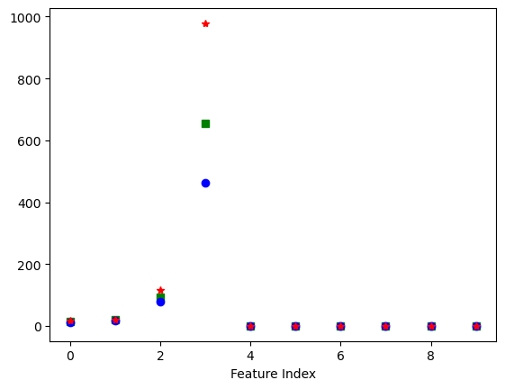

```python
# show the mean feature vectors using matplotlib
from matplotlib import pyplot as plt
mean_ftrs_plot = plt.plot(range(0, 10), ftrs_mean, 'gs')
print(mean_ftrs_plot)

#show the mean feature vector of benign samples using blue dots
#plt.plot
ben_ftrs_plot = plt.plot(range(0, 10), ben_ftrs_mean, 'bo')
print(ben_ftrs_plot)

#show the mean feature vector of malignant samples using red star
mal_ftrs_plot = plt.plot(range(0, 10), mal_ftrs_mean, 'r*')
plt.xlabel('Feature Index')
print(mal_ftrs_plot)
```

### Task 2: Data search. 10 points.

Let the user input a sample index (0 to 568), and your code will output the feature vector and the corresponding class label of that sample.

```
- Extra 5 points for dealing with abnormal input
- 5 extra points for enabling multiple searches in one run
```

```python
# tip: use the input() function
while True:
    index = input("Please input a sample index: ")
    while index.isnumeric() != True or int(index) > 568 or int(index) < 0:
        if index == 'stop':
            break
        index = input("Please reenter a valid index: ")
    if index == 'stop':
        break
    print('The feature vector selected: ', ftrs[int(index),])
    if tgts[int(index)] == 1:
        print('The class label for this feature vector is: WDBC-Benign')
    else:
        print('The class label for this feature vector is: WDBC-Malignant')
```

```
Please input a sample index: 0
The feature vector selected:  [1.799e+01 1.038e+01 1.228e+02 1.001e+03 1.184e-01 2.776e-01 3.001e-01
 1.471e-01 2.419e-01 7.871e-02]
The class label for this feature vector is: WDBC-Malignant
Please input a sample index: 97
The feature vector selected:  [9.787e+00 1.994e+01 6.211e+01 2.945e+02 1.024e-01 5.301e-02 6.829e-03
 7.937e-03 1.350e-01 6.890e-02]
The class label for this feature vector is: WDBC-Benign
Please input a sample index: 81032
Please reenter a valid index: 123d
Please reenter a valid index: 4/2
Please reenter a valid index: 2.3
Please reenter a valid index: stop
```

### Task 3. Study the 'area' feature. 30 points

- Task 3.1: Calculate and print out the mean, min and max values
- Task 3.2: Calculate and print out the mean, min and max values
- What observations can you get from the results of Tasks 3.1 and 3.2?

```
The mean of the feature 'area' for all benign samples is 462.7901960784313
The minimum value of the feature 'area' for all benign samples is 143.5
the maximum value of the feature 'area' for all benign samples is 992.1
```

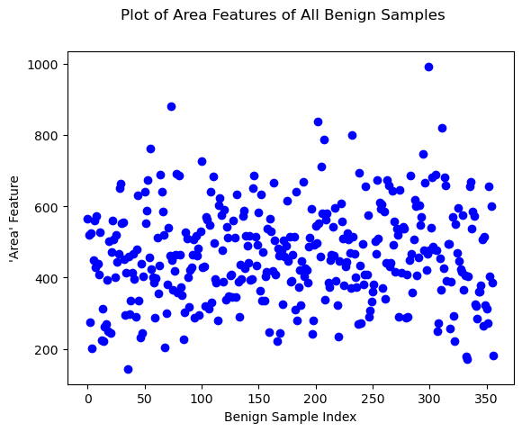

```python
#Task 3.1: Calculate and print out the mean, min and max values
# of the feature 'area (index 3)' for all benign samples.
ben_area_mean = ben_array[0:357, 3].mean(axis = 0)
ben_area_min = ben_array[0:357, 3].min(axis = 0)
ben_area_max = ben_array[0:357, 3].max(axis = 0)

print("The mean of the feature 'area' for all benign samples is", ben_area_mean)
print("The minimum value of the feature 'area' for all benign samples is", ben_area_min)
print("the maximum value of the feature 'area' for all benign samples is", ben_area_max)

# plot the area features of all benign samples
ben_area_plot = plt.plot(range(0, 357), ben_array[0:357, 3], 'bo')
plt.ylabel("'Area' Feature")
plt.xlabel("Benign Sample Index")
plt.suptitle("Plot of Area Features of All Benign Samples")

print(ben_area_plot)
```

```
The mean of the feature 'area' for all malignant samples is 978.3764150943397
The minimum value of the feature 'area' for all malignant samples is 361.6
the maximum value of the feature 'area' for all malignant samples is 2501.0
```

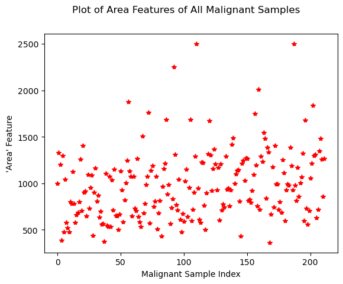

```python
#Task 3.2: Calculate and print out the mean, min and max values
# of the feature 'area (index 3)' for all malignant samples.
mal_area_mean = mal_array[0:212, 3].mean(axis = 0)
mal_area_min = mal_array[0:212, 3].min(axis = 0)
mal_area_max = mal_array[0:212, 3].max(axis = 0)

print("The mean of the feature 'area' for all malignant samples is", mal_area_mean)
print("The minimum value of the feature 'area' for all malignant samples is", mal_area_min)
print("the maximum value of the feature 'area' for all malignant samples is", mal_area_max)

# plot the area features of all malignant samples
mal_area_plot = plt.plot(range(0, 212), mal_array[0:212, 3], 'r*')
plt.ylabel("'Area' Feature")
plt.xlabel("Malignant Sample Index")
plt.suptitle("Plot of Area Features of All Malignant Samples")

print(mal_area_plot)
```

#### Task 3.3: What observations can you get from the results of Tasks 3.1 and 3.2?

Response:

From the results of task 3.1 and 3.2, we see that the average area of a malignant sample (approximately 978.38) is much larger than the average area of a benign sample (approximately 462.79). Additionally, we see that both the minimum and maximum of the area feature for the malignant samples are significantly larger than the corresponding minimum and maximum for the benign samples. Therefore, if we were to get a sample feature vector from a patient with an area of 978 or greater, then it is likely that the sample is malignant.

### Task 4: Count data samples. 10 points

```python
# Task 4.1 Count the number of malignant samples that have 'area (index 3)' values less than 600. 10 points
mal_l600 = 0
L = list(range(0,569))
for i in L:
    if tgts[i] == 0 and ftrs[i,3] < 600:
        mal_l600 = mal_l600 + 1
print("The number of malignant samples that have 'area' values less than 600 is", mal_l600, "samples")
```

```
The number of malignant samples that have 'area' values less than 600 is 31 samples
```

```python
# Task 4.2 Count the number of benign samples that have 'area (index 3)' values less than 600. 10 points
ben_l600 = 0
L = list(range(0,569))
for i in L:
    if tgts[i] == 1 and ftrs[i,3] < 600:
        ben_l600 = ben_l600 + 1
print("The number of benign samples that have 'area' values less than 600 is", ben_l600, "samples")
```

```
The number of benign samples that have 'area' values less than 600 is 304 samples
```

### Task 5. 20 points

Define a function that calculates and return the Euclidean distance between any two given data samples

```python
# Task 5.1 impliment the Euclidean function
def Euclidean(a, b):
    '''
        inputs: a, b: feature vectors of two patients

        return: d: the distance
    '''
    d = np.sqrt(np.sum((a - b)**2))

    return d

# test
print('two malignant samples:', Euclidean(ftrs[1], ftrs[2])) # two malignant samples
print('two benign samples:', Euclidean(ftrs[19], ftrs[20])) # two benign samples
print('between two mean vectors:', Euclidean(ben_ftrs_mean, mal_ftrs_mean)) # between means
```

```
two malignant samples: 123.08662898837753
two benign samples: 46.35812850705252
between two mean vectors: 516.9734937120692
```

```python
# Task 5.2 calculate and print out the Euclidean distance between each feature vector
# and the mean feature vector of maliganant samples
L = list(range(0, 569))
E_distances = np.zeros((569))

for i in L:
    E_distances[i] = Euclidean(ftrs[i, 0:10], mal_ftrs_mean)

print('The Euclidean distances between each feature vector and the mean feature vector of malignant samples is: \n', E_distances)
```

```
The Euclidean distances between each feature vector and the mean feature vector of malignant samples is:
 [  26.33286841  348.10054795  225.11112082  593.5125408   319.32932515
  502.4077818    61.79532584  401.28462001  459.44398605  503.48703014
  181.03324648  197.76883066  145.66845222  196.04450675  400.68669075
  320.18765226  294.61617129  179.73066217  282.0138745   413.10237696
  459.3986358   706.72638157  274.38487304  426.20173653   73.97606495
   65.88638398  334.0717584   115.83316745  246.35464119   24.18488049
  110.09086874  539.11495931   79.15495354  184.12407155  171.42636
  109.00606563  346.07460671  455.78773691  280.3124855   420.0624745
  416.41993896  608.86482115  126.33865143  434.10552387  447.89924741
   98.0677369   779.15097662  444.77872094  530.46489148  418.36475442
  552.00442985  407.60210529  542.26703731   54.92812871  266.20370699
  570.96333651  173.95437402  322.09829911  452.39126515  756.45776132
  668.48445251  759.0599564   333.23137589  719.76084985  480.51774357
  310.61678902  711.17161275  585.93629249  730.13305574  477.13956876
  151.85452113  736.63528284   49.07765063  395.12390877  508.81568826
  161.08876206  420.22837319   28.57520929  268.14933432  473.20777676
  578.40282266  459.33944898  901.41269231  154.31617914  536.51452854
   96.84790559  330.86439527   97.90668591  513.5363054   327.1380648
  316.38265702  250.64705535  427.84943913  424.28459659  273.20845952
  286.1483296   528.65341879  685.99185026  567.35989718  336.54390096
  396.65123596  838.04439013  521.10245358  682.06297987  644.10613878
  449.12171746  567.34154528  513.0009063   531.96775675  583.48689042
  690.26221066  499.1070488   348.93754186  645.9077887   749.91597364
  541.19997096  735.43234464  296.40119517  196.02643615    4.15755488
  576.74257082   98.91702205  784.30350287  338.51669016  425.9347317
  390.64701173  406.74431496  159.85580959  304.34000012  214.19350588
  523.92719165  229.9014898   168.83044301  217.23096087   96.75000646
  473.29795034  556.31501491  580.18571055  300.8842633   595.17519601
  692.10662007  165.73837947  581.92008978  467.30479435  624.92580158
  546.91948492  547.63827384  289.43234505  339.0267264   394.35372274
  460.10296803  777.01726329  680.20834968  598.22780943  440.5686166
  519.44188271   14.84363618   98.44864336  531.27682638  613.4510199
  559.98576793  179.05593697  236.15693095  515.12809296  708.60037068
  288.87701977  622.67198666   92.321169      6.98097441  293.14997282
  515.67915414  414.05489091  242.02225244  607.43002878  630.666172
  753.72997767  677.93137143  145.61393209  453.22788993  470.91171963
 1273.41091266  333.80154636  212.26094058  577.96307784  268.29105188
  662.96114812   62.78579487  559.60450173  550.98250656  516.02894629
  369.09145096  472.17876467  692.48683236  502.19709737  307.35620419
```

[output cut: 60 more lines]

```
  298.11287544  493.89396269  499.54166015   89.91856704  342.37392252
  289.50587244  383.19764317  503.28596734  704.60655655  731.76068428
  707.82759266  526.52990283  613.51450104  159.04863845  247.36618127
  553.82814159  298.4873634   422.5434052   320.38211648  277.09073361
  588.75957782   73.8358724   236.12545666  486.29356852  485.73662266
  722.79058362  864.10896925  591.95411266  408.27397863  687.24230637
  759.61639563  428.21624614  511.28678757  385.10109665  534.58560122
  556.92133002  563.64072419  403.87328299  321.22146435  614.44290542
  330.40143912  349.26059993  573.34024668  802.47935648  810.81964493
  576.98984039  322.60137521  310.50036625  441.09906608  394.42523694
  406.17633559  655.4507141   659.49652582  694.84996033  618.56612811
  619.68568598  601.61247546  471.79274635  716.64204893  465.31880289
  658.91969996  668.63952197  709.37220791  321.8509243   576.36107545
  378.792664    594.14397891  261.91487462  369.69061714  501.34897122
  283.15737605  120.6607482   287.80976386  800.28796916]
```